# 6372 Project 1 - Life Expectancy

By Kristi Herman, Bo Yun, Eric Romero, Neil Benson

09/20/2020

# Introduction

## Importing the necessary libraries

```r
library(ggplot2)
library(ggthemes)
library(gridExtra)
library(tidyverse)
library(plyr)
library(dplyr)
library(naniar) #keep
library(zoo)


# create not in operator
`%notin%` <- Negate(`%in%`)
```

## Introduction

What factors impact life expectancy? Can life expectancy be predicted? The World Health Organization (WHO) maintains a database with life expectancy information for all countries by year along with other variables that could contribute to life expectancy. The data falls into four main areas: health, economic, social, and immunization. This project makes use of the WHO data to better understand life expectancy and how to predict it. In this paper, three different models will be explored: 1) A regression model to identify key relationships between life expectancy and factors related to health, economic, social, and immunization. 2) A parametric regression model to predict life expectancy. 3) A non-parametric regression model to predict life expectancy.

## Data Description

The Life Expectancy dataset used in this analysis was collected from the WHO and made available at Kaggle: https://www.kaggle.com/kumarajarshi/life-expectancy-who. It includes data from 193 countries for the years 2000 – 2015. The 2938 rows contained in the dataset include average life expectancy per country for each year. In addition to the average life expectancy, there are 21 columns of data related to health, economic, social, and immunization.

## Exploratory Data Analysis

## Importing and Cleaning the Data

```r
########### Loading the data
life_ex_DF <- read.csv("https://raw.githubusercontent.com/kristxh/Applied_Stats_Project1/master/datasets_12603_17232_Life_Expectancy_Data.csv")

# cleaning up column names
colnames(life_ex_DF) <- tolower(colnames(life_ex_DF))
colnames(life_ex_DF) <- gsub("\\.\\.",".",colnames(life_ex_DF))
colnames(life_ex_DF) <- gsub("\\.","_",colnames(life_ex_DF))
names(life_ex_DF)[19] <- "thinness_10_19_years"

# converting status and year to factor columns
life_ex_DF$status <- as.factor(life_ex_DF$status)
```

## Checking for missing data

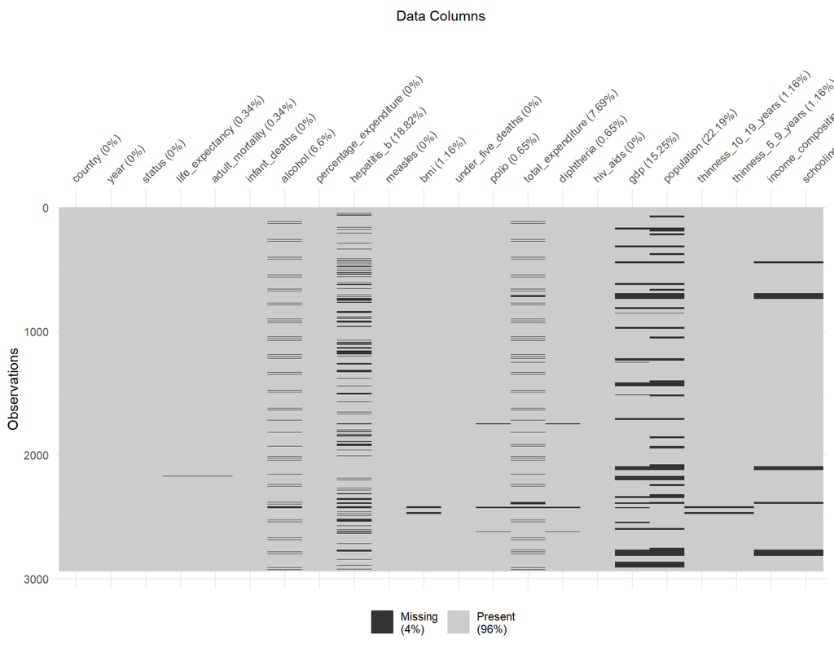

```r
# checking for missing values in the data
vis_miss(life_ex_DF) + xlab("Data Columns")
```

## Fix missing data

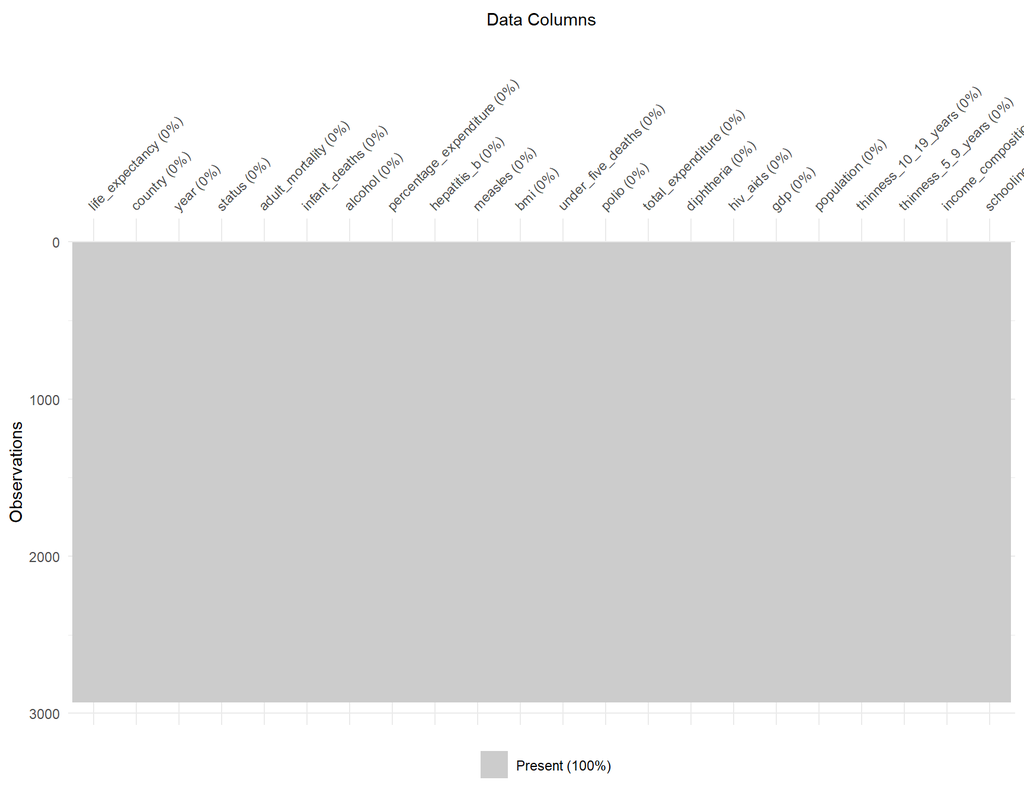

```r
# sorting the columns so that life_expectancy column is first
life_ex_DF <- life_ex_DF %>% select("life_expectancy", everything())

factorcols <- c("status","country","year")
allcols <- colnames(life_ex_DF)

# selecting only numerical columns for correlation
corvars <- allcols[allcols %notin% factorcols]


# impute with median missing values per country
life_ex_median_DF <- as.data.frame(life_ex_DF %>%
  group_by(country) %>%
  mutate_at(corvars, na.aggregate, FUN=median))


# dropping rows where the country has a single entry/record in the dataset and their records are mostly incomplete
life_ex_median_DF <- life_ex_median_DF[!is.na(life_ex_median_DF$life_expectancy), ]


# imputing the median by country still left a few nulls throughout. We will then impute the rest of the missing values as the mean of status (developing, developed, by year)
life_ex_cleaned_DF <- as.data.frame(life_ex_median_DF %>%
  group_by(status,year) %>%
  mutate_at(corvars, na.aggregate, FUN=median))

# checking for missing values in the data
vis_miss(life_ex_cleaned_DF) + xlab("Data Columns")
```

## Summary of cleaned up data

```r
summary(life_ex_cleaned_DF)
```

```
##  life_expectancy   country               year             status
##  Min.   :36.30   Length:2928        Min.   :2000   Developed : 512
##  1st Qu.:63.10   Class :character   1st Qu.:2004   Developing:2416
##  Median :72.10   Mode  :character   Median :2008
##  Mean   :69.22                      Mean   :2008
##  3rd Qu.:75.70                      3rd Qu.:2011
##  Max.   :89.00                      Max.   :2015
##  adult_mortality infant_deaths        alcohol        percentage_expenditure
##  Min.   :  1.0   Min.   :   0.00   Min.   : 0.0100   Min.   :    0.000
##  1st Qu.: 74.0   1st Qu.:   0.00   1st Qu.: 0.9475   1st Qu.:    4.854
##  Median :144.0   Median :   3.00   Median : 3.7350   Median :   65.611
##  Mean   :164.8   Mean   :  30.41   Mean   : 4.6096   Mean   :  740.321
##  3rd Qu.:228.0   3rd Qu.:  22.00   3rd Qu.: 7.6850   3rd Qu.:  442.614
##  Max.   :723.0   Max.   :1800.00   Max.   :17.8700   Max.   :19479.912
##   hepatitis_b       measles              bmi       under_five_deaths
##  Min.   : 1.00   Min.   :     0.0   Min.   : 1.0   Min.   :   0.00
##  1st Qu.:75.00   1st Qu.:     0.0   1st Qu.:19.4   1st Qu.:   0.00
##  Median :91.00   Median :    17.0   Median :43.0   Median :   4.00
##  Mean   :80.23   Mean   :  2427.9   Mean   :38.2   Mean   :  42.18
##  3rd Qu.:96.00   3rd Qu.:   362.2   3rd Qu.:56.1   3rd Qu.:  28.00
##  Max.   :99.00   Max.   :212183.0   Max.   :77.6   Max.   :2500.00
##      polio       total_expenditure   diphtheria       hiv_aids
##  Min.   : 3.00   Min.   : 0.370    Min.   : 2.00   Min.   : 0.100
##  1st Qu.:77.75   1st Qu.: 4.260    1st Qu.:78.00   1st Qu.: 0.100
##  Median :93.00   Median : 5.710    Median :93.00   Median : 0.100
##  Mean   :82.41   Mean   : 5.906    Mean   :82.19   Mean   : 1.748
##  3rd Qu.:97.00   3rd Qu.: 7.452    3rd Qu.:97.00   3rd Qu.: 0.800
##  Max.   :99.00   Max.   :17.600    Max.   :99.00   Max.   :50.600
##       gdp              population        thinness_10_19_years
##  Min.   :     1.68   Min.   :3.400e+01   Min.   : 0.100
##  1st Qu.:   560.98   1st Qu.:4.181e+05   1st Qu.: 1.600
##  Median :  1633.12   Median :1.397e+06   Median : 3.400
##  Mean   :  6848.77   Mean   :1.028e+07   Mean   : 4.849
##  3rd Qu.:  5427.25   3rd Qu.:4.593e+06   3rd Qu.: 7.100
##  Max.   :119172.74   Max.   :1.294e+09   Max.   :27.700
##  thinness_5_9_years income_composition_of_resources   schooling
##  Min.   : 0.100     Min.   :0.0000                  Min.   : 0.00
##  1st Qu.: 1.600     1st Qu.:0.5040                  1st Qu.:10.30
##  Median : 3.400     Median :0.6750                  Median :12.32
##  Mean   : 4.878     Mean   :0.6315                  Mean   :12.05
##  3rd Qu.: 7.200     3rd Qu.:0.7802                  3rd Qu.:14.30
##  Max.   :28.600     Max.   :0.9480                  Max.   :20.70
```

```r
str(life_ex_cleaned_DF)
```

```
## 'data.frame':    2928 obs. of  22 variables:
##  $ life_expectancy                : num  65 59.9 59.9 59.5 59.2 58.8 58.6 58.1 57.5 57.3 ...
##  $ country                        : chr  "Afghanistan" "Afghanistan" "Afghanistan" "Afghanistan" ...
##  $ year                           : int  2015 2014 2013 2012 2011 2010 2009 2008 2007 2006 ...
##  $ status                         : Factor w/ 2 levels "Developed","Developing": 2 2 2 2 2 2 2 2 2 2 ...
##  $ adult_mortality                : num  263 271 268 272 275 279 281 287 295 295 ...
##  $ infant_deaths                  : num  62 64 66 69 71 74 77 80 82 84 ...
##  $ alcohol                        : num  0.01 0.01 0.01 0.01 0.01 0.01 0.01 0.03 0.02 0.03 ...
##  $ percentage_expenditure         : num  71.3 73.5 73.2 78.2 7.1 ...
##  $ hepatitis_b                    : num  65 62 64 67 68 66 63 64 63 64 ...
##  $ measles                        : num  1154 492 430 2787 3013 ...
##  $ bmi                            : num  19.1 18.6 18.1 17.6 17.2 16.7 16.2 15.7 15.2 14.7 ...
##  $ under_five_deaths              : num  83 86 89 93 97 102 106 110 113 116 ...
##  $ polio                          : num  6 58 62 67 68 66 63 64 63 58 ...
##  $ total_expenditure              : num  8.16 8.18 8.13 8.52 7.87 9.2 9.42 8.33 6.73 7.43 ...
##  $ diphtheria                     : num  65 62 64 67 68 66 63 64 63 58 ...
##  $ hiv_aids                       : num  0.1 0.1 0.1 0.1 0.1 0.1 0.1 0.1 0.1 0.1 ...
##  $ gdp                            : num  584.3 612.7 631.7 670 63.5 ...
##  $ population                     : num  33736494 327582 31731688 3696958 2978599 ...
##  $ thinness_10_19_years           : num  17.2 17.5 17.7 17.9 18.2 18.4 18.6 18.8 19 19.2 ...
##  $ thinness_5_9_years             : num  17.3 17.5 17.7 18 18.2 18.4 18.7 18.9 19.1 19.3 ...
##  $ income_composition_of_resources: num  0.479 0.476 0.47 0.463 0.454 0.448 0.434 0.433 0.415 0.405 ...
##  $ schooling                      : num  10.1 10 9.9 9.8 9.5 9.2 8.9 8.7 8.4 8.1 ...
```

```r
t(aggregate(life_expectancy~status,data=life_ex_cleaned_DF,summary))
```

```
##                         [,1]        [,2]
## status                  "Developed" "Developing"
## life_expectancy.Min.    "69.90000"  "36.30000"
## life_expectancy.1st Qu. "76.80000"  "61.10000"
## life_expectancy.Median  "79.25000"  "69.00000"
## life_expectancy.Mean    "79.19785"  "67.11147"
## life_expectancy.3rd Qu. "81.70000"  "74.00000"
## life_expectancy.Max.    "89.00000"  "89.00000"
```

```r
t(aggregate(life_expectancy~status,data=life_ex_cleaned_DF,sd))
```

```
##                 [,1]        [,2]
## status          "Developed" "Developing"
## life_expectancy "3.930942"  "9.006092"
```

BMI has some very weird mins and maxes. Will explore further, but this data may later show correlations that aren’t actually there because the min and max of BMI are not practical or possible.

## Histogram of life_expectancy

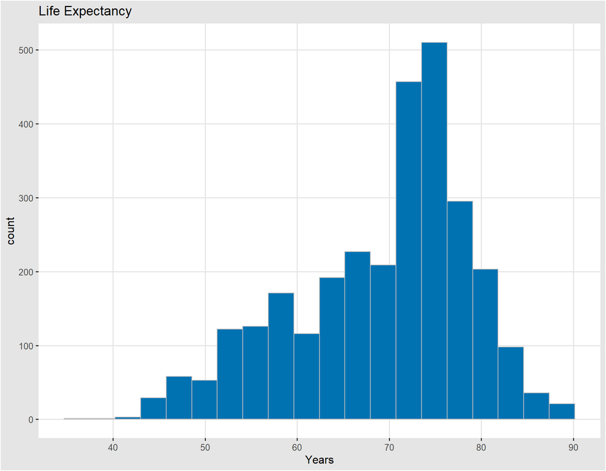

```r
theme_set(theme_igray())

le_hist <- geom_histogram(
  mapping = aes(life_expectancy),
  data = life_ex_cleaned_DF,
  bins = 20,
  colour = "gray",
  fill = "#0072B2"
)

ggplot()+ le_hist + xlab("Years") + ggtitle("Life Expectancy")
```

## Overall Life Expectancy

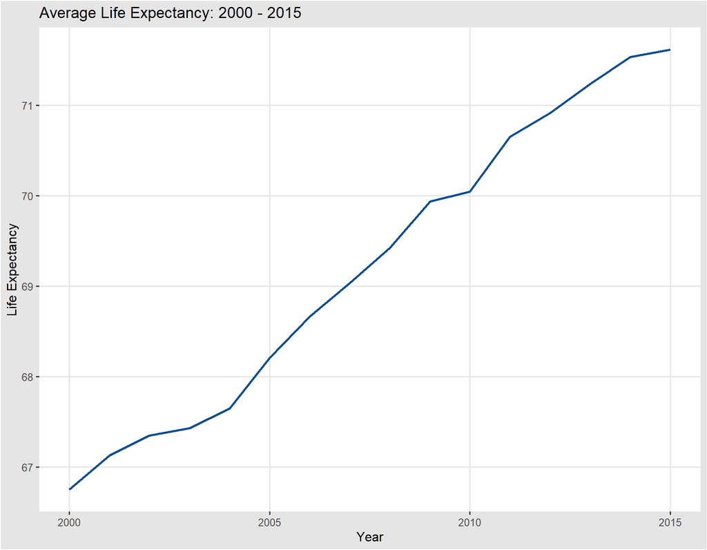

```r
le_by_yr <- ddply(life_ex_cleaned_DF, .(year), summarize,  avg_le=mean(life_expectancy))

le_line <- geom_line(
  mapping = aes(x = year, y = avg_le),
  data = le_by_yr,
  size = 1,
  colour = "dodgerblue4"
)

ggplot() + le_line + xlab("Year") + ylab("Life Expectancy") + ggtitle("Average Life Expectancy: 2000 - 2015")
```

Life Expectancy is linearly related to year, and year should be treated as continuous instead of as a factor in this model. We will drop BMI for having unrealistic range of data, and no way to correct for it.

## Developed/Developing Life Expectancy

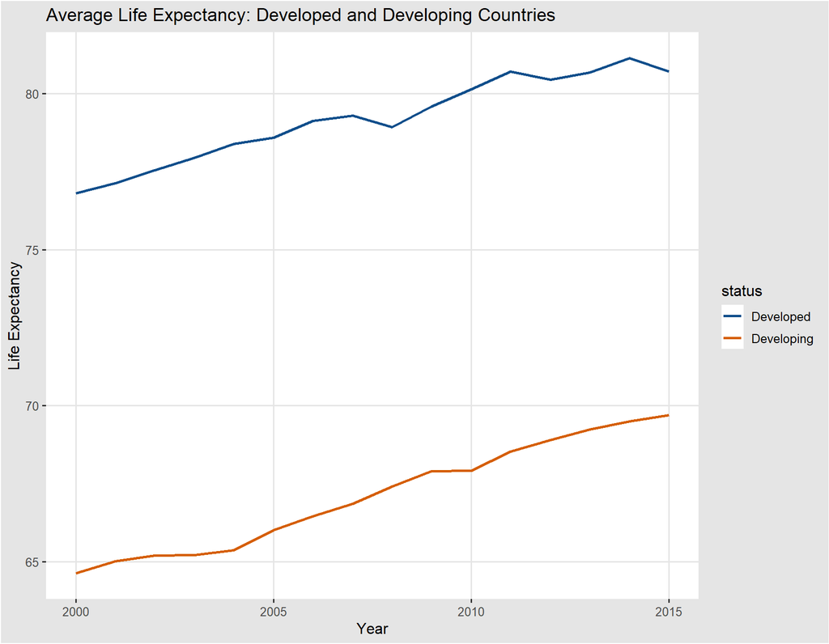

```r
le_by_status <- ddply(life_ex_cleaned_DF, .(year,status), summarize,  avg_le=mean(life_expectancy))
line_colors <- c("dodgerblue4", "#D55E00")

le_line2 <- geom_line(
  mapping = aes(x = year, y = avg_le, group=status, color=status),
  data = le_by_status,
  size = 1
)

ggplot() + le_line2 +  xlab("Year") + ylab("Life Expectancy") + ggtitle("Average Life Expectancy: Developed and Developing Countries") + scale_colour_manual(values=line_colors)
```

## Boxplot by status (developing, developed)

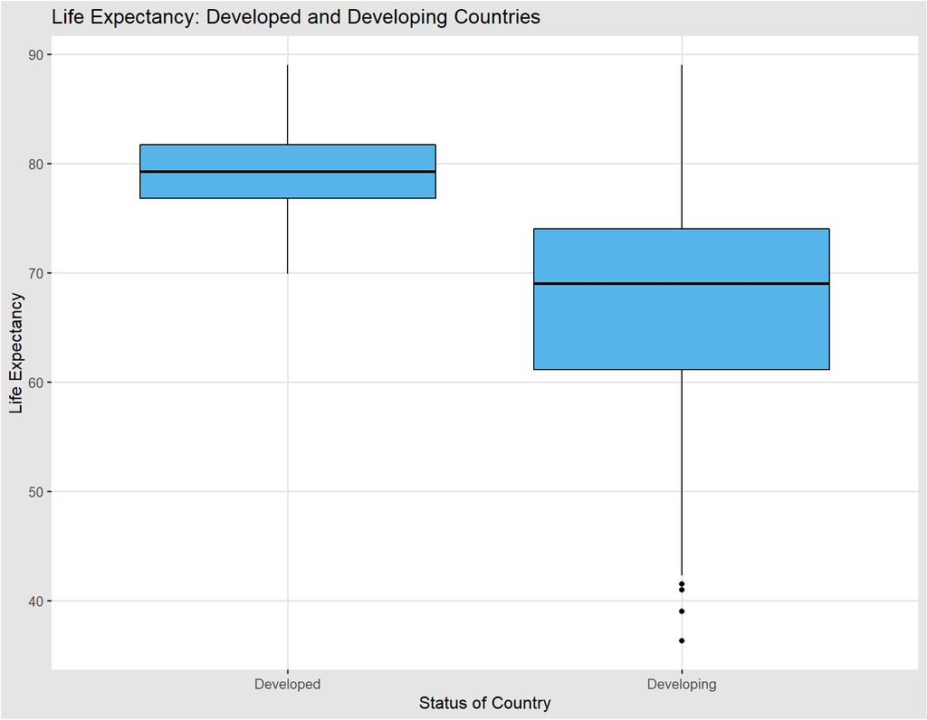

```r
# Plot boxplot

dev_box <- geom_boxplot(
  mapping = aes(x=status, y=life_expectancy),
  data = life_ex_cleaned_DF,
  colour = "black",
  fill = "#56B4E9",
  groupColors=c('#999999','#E69F00')
)
ggplot()+ dev_box + xlab("Status of Country") + ylab("Life Expectancy") + ggtitle("Life Expectancy: Developed and Developing Countries ")
```

There appears to be enough of a difference between `life_expectancy` mean by developed and developing `status`. We will perform an anova and analyze signifance in the difference in means.

## Boxplots by status by year

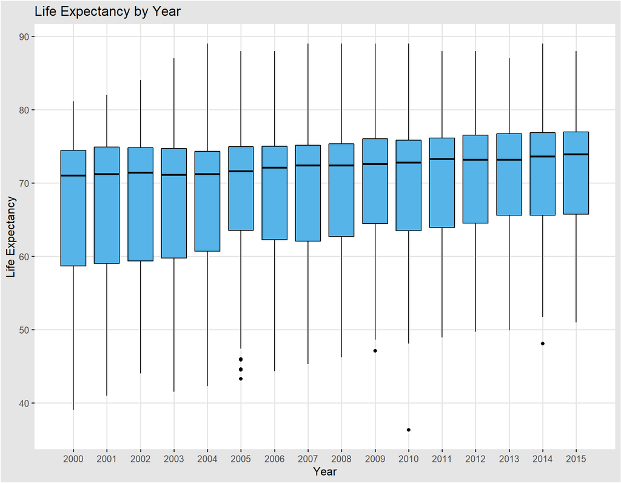

```r
# Plot boxplot

yr_box <- stat_boxplot(
  mapping = aes(x=year, y=life_expectancy, group=year),
  data = life_ex_cleaned_DF,
  colour = "black",
  fill = "#56B4E9"
  )


ggplot()+ yr_box + xlab("Year") + ylab("Life Expectancy") + scale_x_continuous(breaks=c(2000:2015)) + ggtitle("Life Expectancy by Year")
```

## Checking the significance of the factorial variables using ANOVA

```r
# convert categorical variables to factors
names <- c("country", "status")

life_ex_cleaned_factor_DF <- life_ex_cleaned_DF

# set the categorical columns to factor
for (name in names)
{
  life_ex_cleaned_factor_DF[,name]<-factor(life_ex_cleaned_DF[,name])
}

# convert factors to numeric for factor analysis
life_ex_cleaned_asnum_DF <- life_ex_cleaned_factor_DF[,names] %>% mutate_all(as.numeric)

# adding suffix ASNUM to numerical representation of factors columns
colnames(life_ex_cleaned_asnum_DF) <- paste(colnames(life_ex_cleaned_asnum_DF), "ASNUM", sep = "_")

# adding numerical factor columns to base Df in order to perform stepwise for variable selection
life_ex_cleaned_withnum_DF <- cbind(life_ex_cleaned_factor_DF, life_ex_cleaned_asnum_DF)

# dropping factor columns
life_ex_cleaned_withnum_DF <- life_ex_cleaned_withnum_DF[, sapply(life_ex_cleaned_withnum_DF, class) != "factor"]

#  columns for anova factor analysis
anovacols <- c(colnames(life_ex_cleaned_asnum_DF))

#  creating the formula to pass into aov function
anovafmla <- as.formula(paste("life_expectancy ~ ", paste(anovacols, collapse= "+")))

# passing my auto generated formula to analyze
anova_fit <- aov(anovafmla, data=life_ex_cleaned_withnum_DF)
summary(anova_fit)
```

```
##                 Df Sum Sq Mean Sq F value Pr(>F)
## country_ASNUM    1     57      57   0.816  0.367
## status_ASNUM     1  61910   61910 889.749 <2e-16 ***
## Residuals     2925 203524      70
## ---
## Signif. codes:  0 '***' 0.001 '**' 0.01 '*' 0.05 '.' 0.1 ' ' 1
```

### Testing the life_expectancy mean difference by status

Equal means model significance here to test significance of mean difference of `life_expectancy` between status.

H0: μdeveloped = μdeveloping  
Ha: μdeveloped ≠ μdeveloping

Reject H0 that the means are equal

This is statistically significant (p-value <2e-16), and we will include status as a factor to consider in the model.

Later will remove `country` from the data set for variable selection (p-value 0.367).

## Scatterplot boxplot

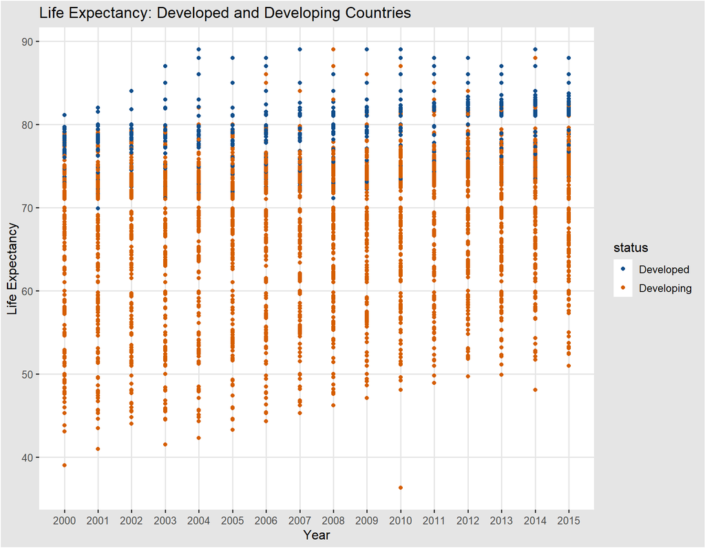

```r
le_scatter <- geom_point(
  mapping = aes(x=year, y=life_expectancy, color=status),
  data = life_ex_cleaned_DF
  )


ggplot()+ le_scatter + xlab("Year") + ylab("Life Expectancy") + scale_x_continuous(breaks=c(2000:2015)) + ggtitle("Life Expectancy: Developed and Developing Countries")  + scale_colour_manual(values=line_colors)
```

## Correlation matrix with pearson correlation coefficients

```r
library(reshape2)
```

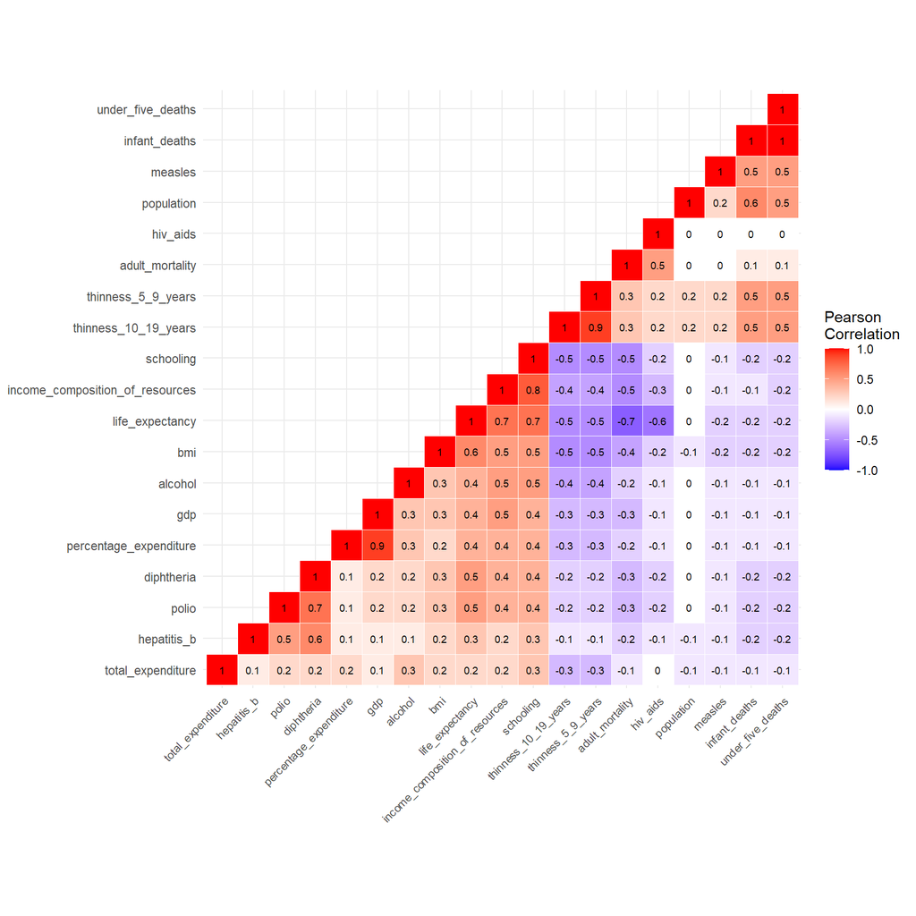

```r
corr <- round(cor(life_ex_cleaned_DF[,corvars]),1)
melted_cormat <- melt(corr)


# Get lower triangle of the correlation matrix
  get_lower_tri<-function(cormat){
    cormat[lower.tri(cormat)] <- NA
    return(cormat)
  }


# reorder the correlation matrix
reorder_cormat <- function(cormat){
# Use correlation between variables as distance
dd <- as.dist((1-cormat)/2)
hc <- hclust(dd)
cormat <-cormat[hc$order, hc$order]
}


# reorder the correlation matrix
corr <- reorder_cormat(corr)

# get lower half
lower_half <- get_lower_tri(corr)

# reshape the correlation matrix
melted_cormat <- melt(lower_half, na.rm = TRUE)

# plot it
ggcorrmap <- ggplot(melted_cormat, aes(Var2, Var1, fill = value))+
 geom_tile(color = "white")+
 scale_fill_gradient2(low = "blue", high = "red", mid = "white",
  midpoint = 0, limit = c(-1,1), space = "Lab",
    name="Pearson\nCorrelation") +
  theme_minimal()+
  theme(axis.text.x = element_text(angle = 45, vjust = 1,
    size = 8, hjust = 1), axis.title.x = element_blank(), axis.title.y = element_blank())+
 coord_fixed()


ggcorrmap + geom_text(aes(Var2, Var1, label = value), color = "black", size = 2.5)
```

It appears there is a high degree of correlation between the following:  
- `thinnes_5_9_years` & `thinnes_10_19_years`: 0.9  
- `percentage_expenditure` & `gdp`: 0.9  
- `under_5_deaths` & `infant_deaths`: 1.0  
- `schooling` & `income_composition_of_resources`: 0.8  
- `population` has 0 correlation with the response variable and will be removed as a predictor and is incomplete throughout the data set

## Further examining the issue of multicolinearity

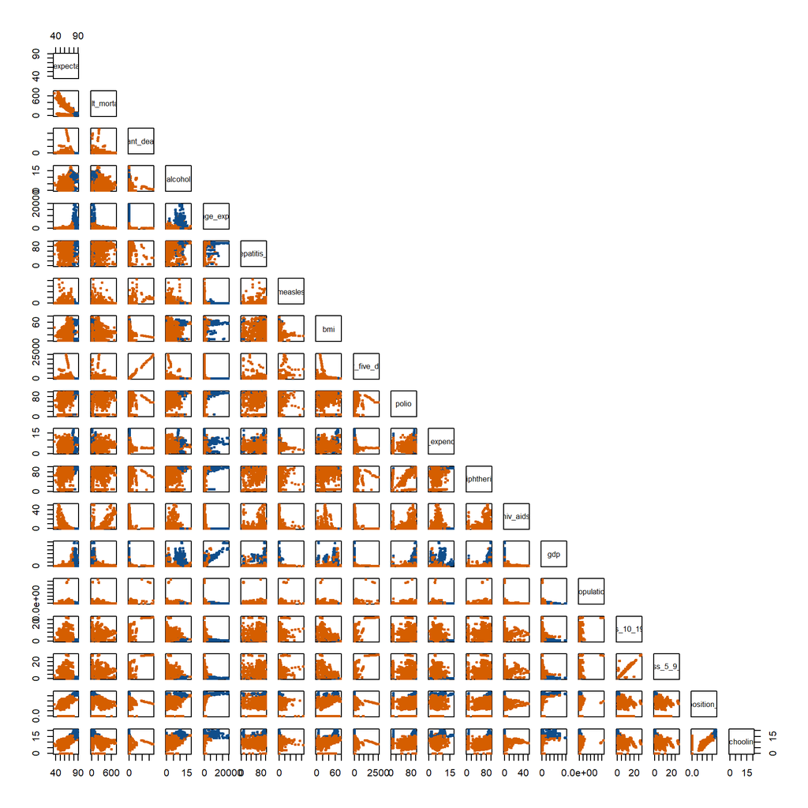

```r
pairs(life_ex_cleaned_DF[,corvars], pch = 19,  cex = 0.5,
      col = line_colors[life_ex_cleaned_DF$status],
      upper.panel=NULL)
```

## Further exploration of hiv_ads and percentage_expenditure

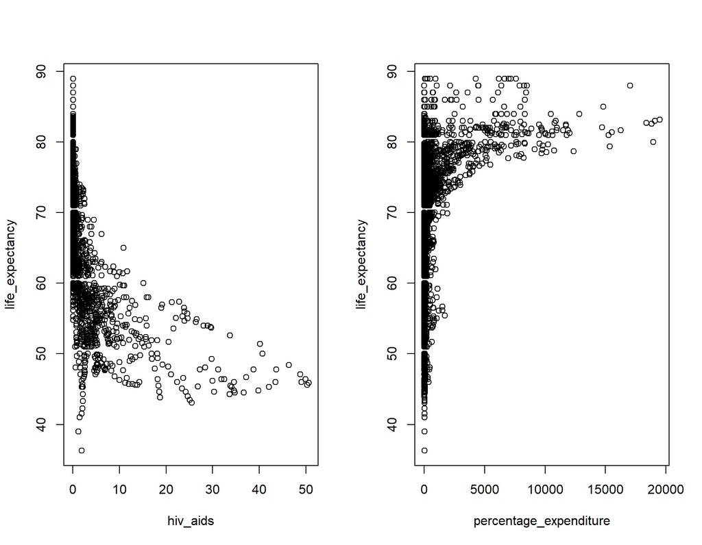

```r
par(mfrow=c(1,2))

plot(life_ex_cleaned_DF$hiv_aids,life_ex_cleaned_DF$life_expectancy, xlab="hiv_aids",ylab="life_expectancy")


plot(life_ex_cleaned_DF$percentage_expenditure,life_ex_cleaned_DF$life_expectancy, xlab="percentage_expenditure",ylab="life_expectancy")
```

It appears that both `hiv_aids` and `percentage_expenditure` have nonlinear relationships with the response variable. We will further investigate.

There also appears to be some interaction between `status` and `percentage_expenditure`, and `status` and `schooling`. Further exploration needed.

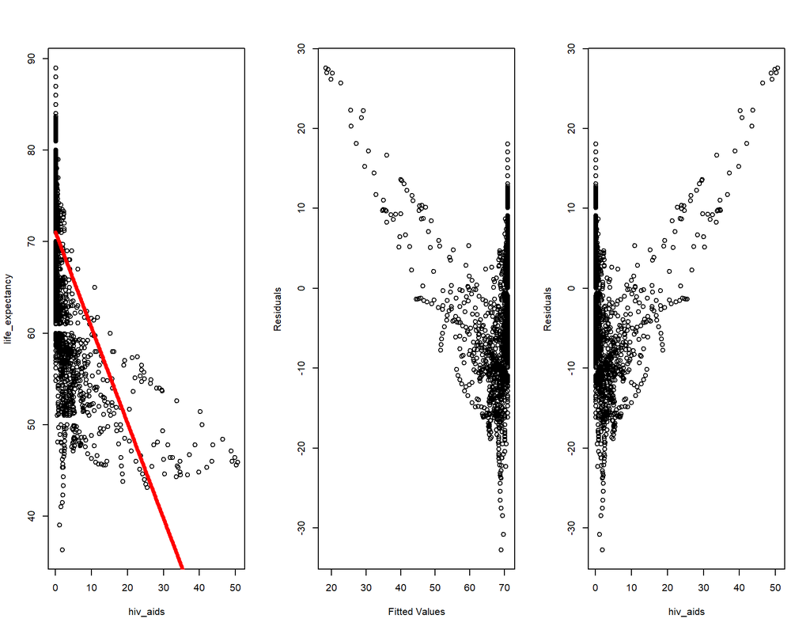

```r
life_expectancy <- life_ex_cleaned_DF$life_expectancy
hiv_aids <- life_ex_cleaned_DF$hiv_aids

hiv_aids.model <- lm(life_expectancy~hiv_aids)

# visually inspecting the reltationship between life_expectancy and hiv_aids before adding complexity
par(mfrow=c(1,3))
plot(hiv_aids,life_expectancy, xlab="hiv_aids",ylab="life_expectancy")
new<-data.frame(hiv_aids=seq(0,50,.1))
lines(seq(0,50,.1),predict(hiv_aids.model,newdata=new),col="red",lwd=4)
plot(hiv_aids.model$fitted.values,hiv_aids.model$residuals,xlab="Fitted Values",ylab="Residuals")
plot(life_ex_cleaned_DF$hiv_aids,hiv_aids.model$residuals,xlab="hiv_aids",ylab="Residuals")
```

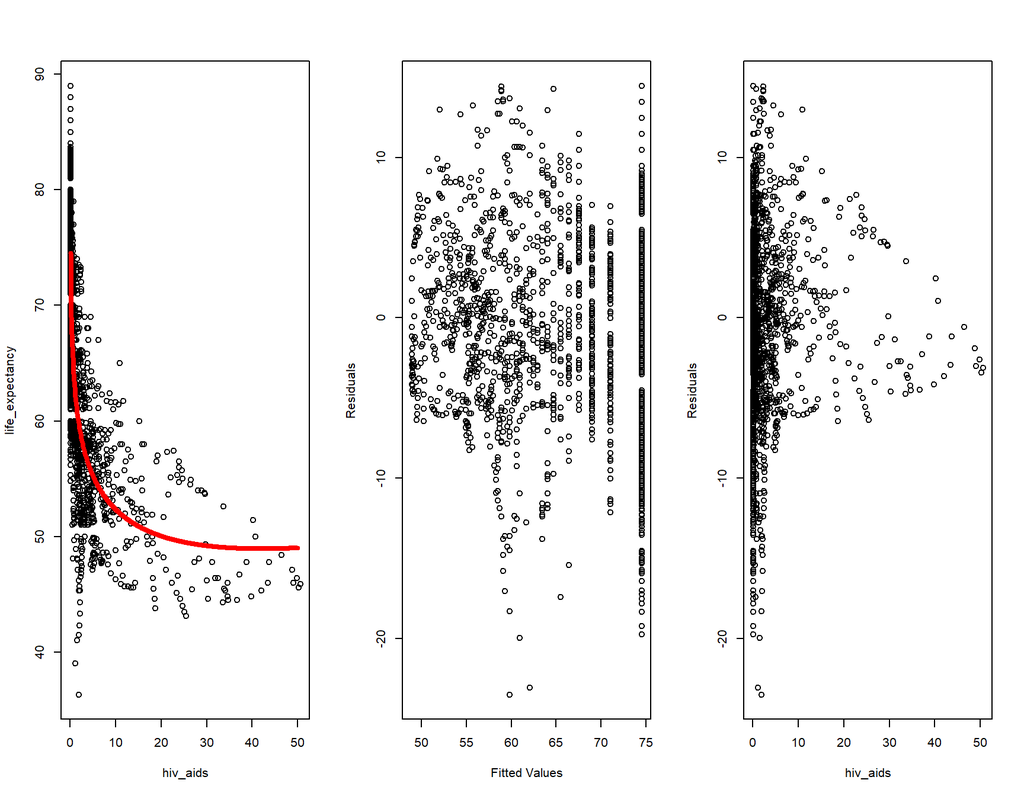

```r
# adding complexity to relationship between life_expectancy and hiv_aids
hiv_aids.model2 <- lm(life_expectancy~hiv_aids+I(log(hiv_aids)))


# visually inspecting the reltationship between life_expectancy and hiv_aids after transformations
par(mfrow=c(1,3))
plot(hiv_aids,life_expectancy, xlab="hiv_aids",ylab="life_expectancy")
new<-data.frame(hiv_aids=seq(0,50,.1))
lines(seq(0,50,.1),predict(hiv_aids.model2,newdata=new),col="red",lwd=4)
plot(hiv_aids.model2$fitted.values,hiv_aids.model2$residuals,xlab="Fitted Values",ylab="Residuals")
plot(life_ex_cleaned_DF$hiv_aids,hiv_aids.model2$residuals,xlab="hiv_aids",ylab="Residuals")
```

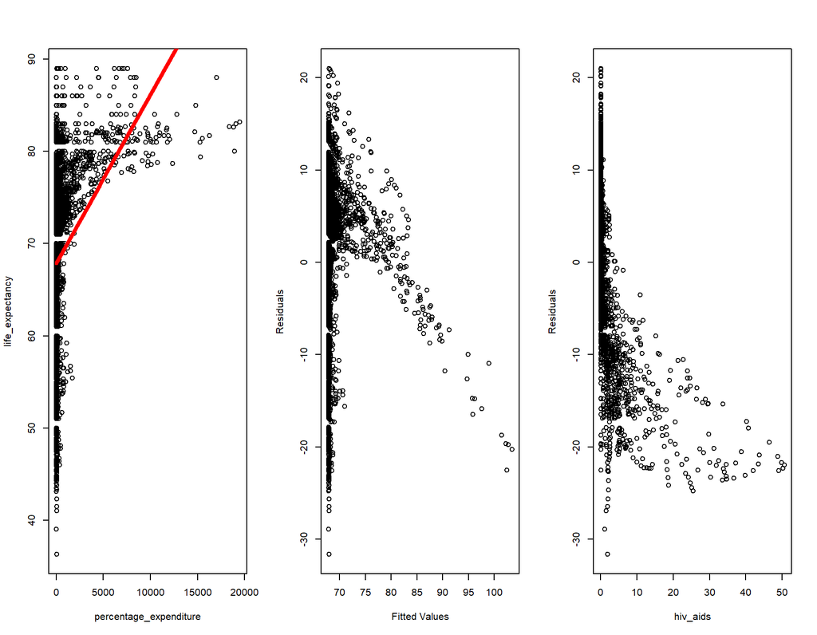

```r
percentage_expenditure <- life_ex_cleaned_DF$percentage_expenditure

perc_exp.model <- lm(life_expectancy~percentage_expenditure)

# visually inspecting the reltationship between life_expectancy and percentage_expenditure before adding complexity
par(mfrow=c(1,3))
plot(percentage_expenditure,life_expectancy, xlab="percentage_expenditure",ylab="life_expectancy")
new2<-data.frame(percentage_expenditure=seq(0,20000,100))
lines(seq(0,20000,100),predict(perc_exp.model,newdata=new2),col="red",lwd=4)
plot(perc_exp.model$fitted.values,perc_exp.model$residuals,xlab="Fitted Values",ylab="Residuals")
plot(life_ex_cleaned_DF$hiv_aids,perc_exp.model$residuals,xlab="hiv_aids",ylab="Residuals")
```

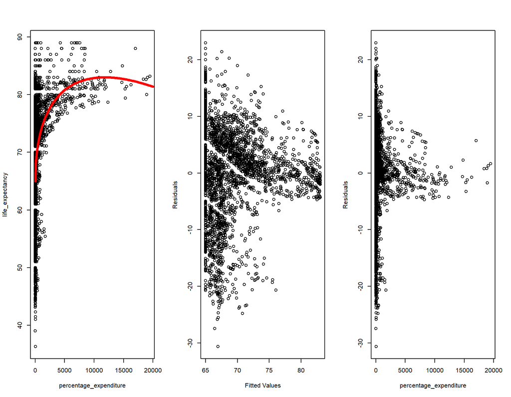

```r
# adding complexity to relationship between life_expectancy and percentage_expenditure
perc_exp.model2 <- lm(life_expectancy~percentage_expenditure+I(sqrt(percentage_expenditure)))


# visually inspecting the reltationship between life_expectancy and percentage_expenditure after transformations
par(mfrow=c(1,3))
plot(percentage_expenditure,life_expectancy, xlab="percentage_expenditure",ylab="life_expectancy")
new2<-data.frame(percentage_expenditure=seq(0,20000,100))
lines(seq(0,20000,100),predict(perc_exp.model2,newdata=new2),col="red",lwd=4)
plot(perc_exp.model2$fitted.values,perc_exp.model2$residuals,xlab="Fitted Values",ylab="Residuals")
plot(life_ex_cleaned_DF$percentage_expenditure,perc_exp.model2$residuals,xlab="percentage_expenditure",ylab="Residuals")
```

## Checking colinearity with VIF and removing redundant columns

```r
library(car)
full.model <- lm(life_expectancy~. ,data=life_ex_cleaned_DF[,corvars])

vif(full.model, data = life_ex_cleaned_DF)
```

```
##                 adult_mortality                   infant_deaths
##                        1.740193                      177.362727
##                         alcohol          percentage_expenditure
##                        1.667368                        4.927272
##                     hepatitis_b                         measles
##                        1.612879                        1.376254
##                             bmi               under_five_deaths
##                        1.753643                      176.345484
##                           polio               total_expenditure
##                        1.980492                        1.194978
##                      diphtheria                        hiv_aids
##                        2.310742                        1.423468
##                             gdp                      population
##                        5.333755                        1.484830
##            thinness_10_19_years              thinness_5_9_years
##                        8.752647                        8.845432
## income_composition_of_resources                       schooling
##                        3.121290                        3.642254
```

```r
# removing columns and re-evaluating
colstodelete <- c("under_five_deaths", "thinness_5_9_years", "gdp", "population", "bmi")

full.model1 <- lm(life_expectancy~. ,data=life_ex_cleaned_DF[,corvars] %>% select(-all_of(colstodelete)))

vif(full.model1, data = life_ex_cleaned_DF[,corvars] %>% select(-all_of(colstodelete)))
```

```
##                 adult_mortality                   infant_deaths
##                        1.709290                        1.703851
##                         alcohol          percentage_expenditure
##                        1.622942                        1.232169
##                     hepatitis_b                         measles
##                        1.605898                        1.352350
##                           polio               total_expenditure
##                        1.969422                        1.177501
##                      diphtheria                        hiv_aids
##                        2.272748                        1.416032
##            thinness_10_19_years income_composition_of_resources
##                        1.787287                        3.034277
##                       schooling
##                        3.535584
```

## Removing columns with high colinearity or low significance

“under_five_deaths”, “thinness_5_9_years”, “gdp”, “population” and “country” Removing “bmi” as a result of unrealistic data

```r
# adding "country" to the list of columns to delete after its poor performance in ANOVA analysis
colstodelete <- append(colstodelete, "country")
Life <- life_ex_cleaned_factor_DF %>% select(-all_of(colstodelete))
```

## Checking residuals and q-q plot of the full model

Including complexity for the terms `hiv_aids` and `percentage_expenditure`.

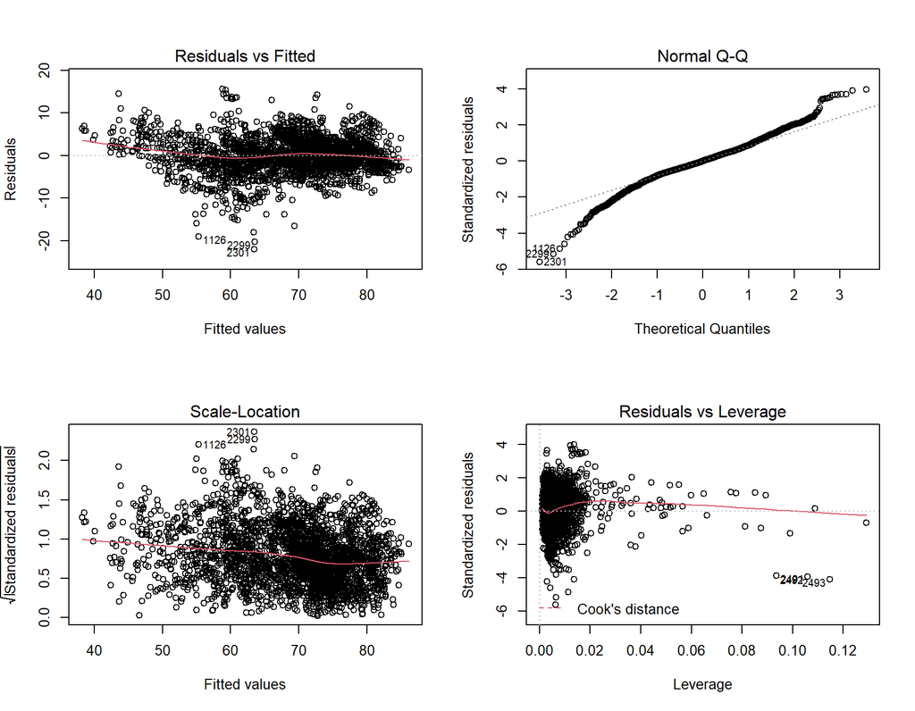

```r
full.model <- lm(life_expectancy~. + I(hiv_aids^2) + I(sqrt(percentage_expenditure)) ,data=Life)
par(mfrow=c(2,2))
plot(full.model)
```

## Adding interaction and checking significance

Visual assessment of pair plots showed potential interactions between the following:  
- `status` >> `percentage_expenditure`  
- `status` >> `schooling`

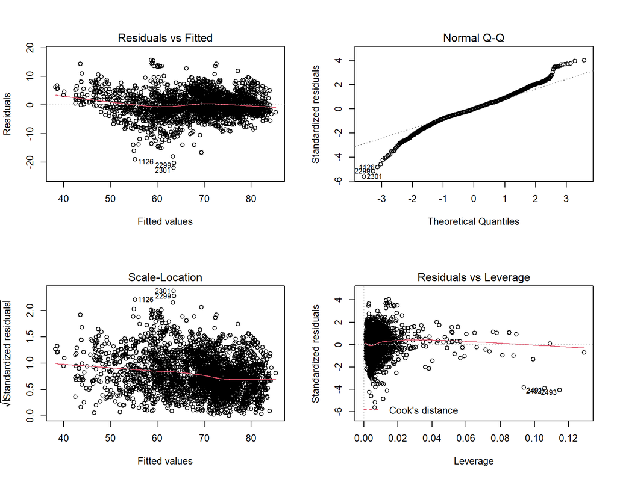

```r
full.modelwinter <- lm(life_expectancy~. + I(hiv_aids^2) + I(sqrt(percentage_expenditure)) + status:percentage_expenditure + status:schooling, data=Life)

# Re-assessing the residual plots and assumptions
par(mfrow=c(2,2))
plot(full.modelwinter)
```

```r
summary(full.modelwinter)
```

```
##
## Call:
## lm(formula = life_expectancy ~ . + I(hiv_aids^2) + I(sqrt(percentage_expenditure)) +
##     status:percentage_expenditure + status:schooling, data = Life)
##
## Residuals:
##      Min       1Q   Median       3Q      Max
## -21.9650  -2.1015  -0.0345   2.1999  15.7021
##
## Coefficients:
##                                           Estimate Std. Error t value Pr(>|t|)
## (Intercept)                              5.514e+01  3.408e+01   1.618 0.105777
## year                                     1.850e-03  1.708e-02   0.108 0.913750
## statusDeveloping                        -3.684e+00  1.769e+00  -2.083 0.037356
## adult_mortality                         -1.649e-02  7.971e-04 -20.684  < 2e-16
## infant_deaths                           -4.656e-04  8.048e-04  -0.578 0.562971
## alcohol                                  3.344e-02  2.546e-02   1.313 0.189165
## percentage_expenditure                  -2.638e-04  9.975e-05  -2.644 0.008227
## hepatitis_b                             -1.005e-03  3.789e-03  -0.265 0.790764
## measles                                 -2.606e-05  7.389e-06  -3.527 0.000427
## polio                                    2.607e-02  4.365e-03   5.972 2.62e-09
## total_expenditure                        5.396e-02  3.262e-02   1.654 0.098189
## diphtheria                               3.420e-02  4.651e-03   7.353 2.51e-13
## hiv_aids                                -1.174e+00  4.169e-02 -28.154  < 2e-16
## thinness_10_19_years                    -1.114e-01  2.218e-02  -5.025 5.35e-07
## income_composition_of_resources          5.871e+00  6.306e-01   9.311  < 2e-16
## schooling                                5.766e-01  1.079e-01   5.345 9.75e-08
## I(hiv_aids^2)                            1.988e-02  1.115e-03  17.824  < 2e-16
## I(sqrt(percentage_expenditure))          5.752e-02  1.033e-02   5.568 2.81e-08
## statusDeveloping:percentage_expenditure  3.991e-04  1.263e-04   3.161 0.001588
## statusDeveloping:schooling               1.477e-01  1.131e-01   1.306 0.191736
##
## (Intercept)
## year
## statusDeveloping                        *
## adult_mortality                         ***
## infant_deaths
## alcohol
## percentage_expenditure                  **
## hepatitis_b
## measles                                 ***
## polio                                   ***
## total_expenditure                       .
## diphtheria                              ***
## hiv_aids                                ***
## thinness_10_19_years                    ***
## income_composition_of_resources         ***
## schooling                               ***
## I(hiv_aids^2)                           ***
## I(sqrt(percentage_expenditure))         ***
## statusDeveloping:percentage_expenditure **
## statusDeveloping:schooling
## ---
## Signif. codes:  0 '***' 0.001 '**' 0.01 '*' 0.05 '.' 0.1 ' ' 1
##
## Residual standard error: 3.935 on 2908 degrees of freedom
## Multiple R-squared:  0.8304, Adjusted R-squared:  0.8293
## F-statistic: 749.5 on 19 and 2908 DF,  p-value: < 2.2e-16
```

Upon further examination, we find that the following are insignificant and will be fruther analyzesd for removal from the model:  
- `year` - `infant_deaths` - `alcohol` - `hepatitis_b` - `total_expenditure` - `status:schooling` interaction

## Splitting the data into test and training sets for cross validation

```r
# Cross Validation on Train vs Test
# Splitting 2939 observations of the data into Training and Test set in the ratio of 70:30
set.seed(1234)
trainIndices = sample(seq(1:dim(Life)[1]),round(.7*dim(Life)[1]))
train = Life[trainIndices,]
test = Life[-trainIndices,]
dim(train)
```

```
## [1] 2050   16
```

```r
dim(test)
```

```
## [1] 878  16
```

## Creating a prediction function

```r
predict.regsubsets = function (object , newdata ,id ,...){
  form=as.formula (object$call [[2]])
  mat=model.matrix(form ,newdata )
  coefi=coef(object ,id=id)
  xvars=names(coefi)
  mat[,xvars]%*%coefi
}
```

## Variable selection - Forward

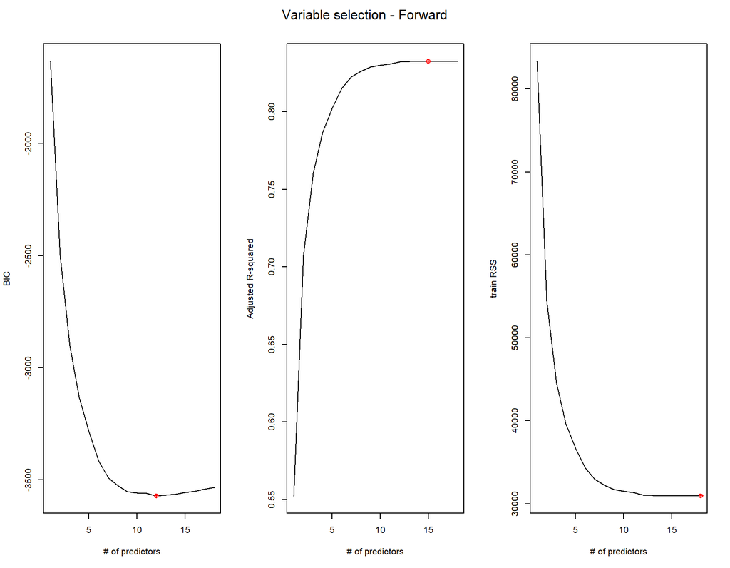

```r
# Just the training set
library(leaps)

reg.fwd=regsubsets(life_expectancy~. + I(hiv_aids^2) + I(sqrt(percentage_expenditure)) + status:percentage_expenditure, data=train, method="forward", nvmax=18)

par(mfrow=c(1,3))

# BIC
bics<-summary(reg.fwd)$bic
plot(1:18,bics,type="l",ylab="BIC",xlab="# of predictors")
index<-which(bics==min(bics))
points(index,bics[index],col="red",pch=10)

# Adjusted R2
adjr2<-summary(reg.fwd)$adjr2
plot(1:18,adjr2,type="l",ylab="Adjusted R-squared",xlab="# of predictors")
index<-which(adjr2==max(adjr2))
points(index,adjr2[index],col="red",pch=10)

# RSS
rss<-summary(reg.fwd)$rss
plot(1:18,rss,type="l",ylab="train RSS",xlab="# of predictors")
index<-which(rss==min(rss))
points(index,rss[index],col="red",pch=10)
mtext("Variable selection - Forward", side = 3, line = -2, outer = TRUE)
```

```r
# -> 12 predictors
```

## Variable selection - Backward

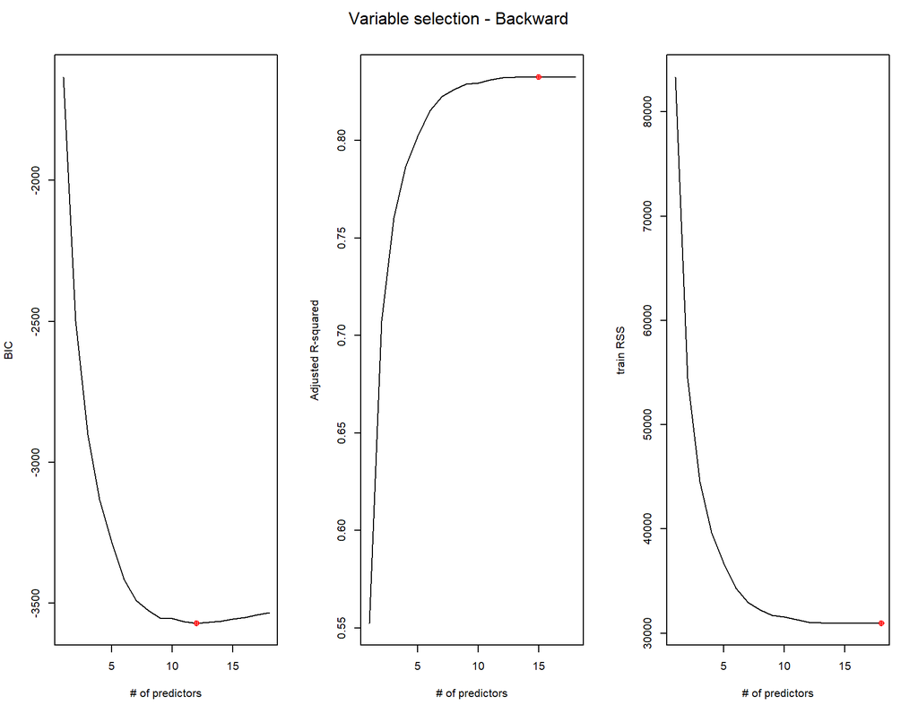

```r
# Just the training set
reg.bwd=regsubsets(life_expectancy~. + I(hiv_aids^2) + I(sqrt(percentage_expenditure)) + status:percentage_expenditure, data=train, method="backward", nvmax=18)

par(mfrow=c(1,3))

# BIC
bics2<-summary(reg.bwd)$bic
plot(1:18,bics2,type="l",ylab="BIC",xlab="# of predictors")
index2<-which(bics2==min(bics2))
points(index2,bics2[index2],col="red",pch=10)

# Adjusted R2
adjr2<-summary(reg.bwd)$adjr2
plot(1:18,adjr2,type="l",ylab="Adjusted R-squared",xlab="# of predictors")
index.r2<-which(adjr2==max(adjr2))
points(index.r2,adjr2[index.r2],col="red",pch=10)

# RSS
rss2<-summary(reg.bwd)$rss
plot(1:18,rss2,type="l",ylab="train RSS",xlab="# of predictors")
index.rss2<-which(rss2==min(rss2))
points(index.rss2,rss[index.rss2],col="red",pch=10)
mtext("Variable selection - Backward", side = 3, line = -2, outer = TRUE)
```

```r
# -> 12 predictors
```

## Variable selection - Stepwise

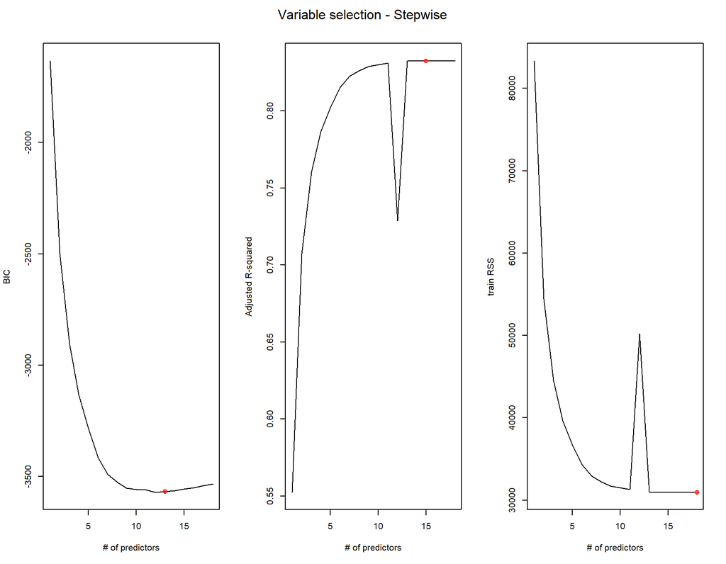

```r
# Just the training set
reg.stp=regsubsets(life_expectancy~. + I(hiv_aids^2) + I(sqrt(percentage_expenditure)) + status:percentage_expenditure, data=train, method="seqrep", nvmax=18)

par(mfrow=c(1,3))

# BIC
bics3<-summary(reg.stp)$bic
plot(1:18,bics,type="l",ylab="BIC",xlab="# of predictors")
index3<-which(bics3==min(bics3))
points(index3,bics[index3],col="red",pch=10)

# Adjusted R2
adjr3<-summary(reg.stp)$adjr
plot(1:18,adjr3,type="l",ylab="Adjusted R-squared",xlab="# of predictors")
index3<-which(adjr3==max(adjr3))
points(index3,adjr3[index3],col="red",pch=10)

# RSS
rss3<-summary(reg.stp)$rss
plot(1:18,rss3,type="l",ylab="train RSS",xlab="# of predictors")
index3<-which(rss3==min(rss3))
points(index3,rss[index3],col="red",pch=10)
mtext("Variable selection - Stepwise", side = 3, line = -2, outer = TRUE)
```

```r
# -> 13 predictors
```